# Getting the Binomial RV from the Bernoulli

In class we defined the Binomial$(n,p)$ random variable as the sum of $n$ independent Bernoulli$(p)$ random variables. In other words, the Binomial$(n,p)$ equals the total number of successes (ones) in $n$ independent Bernoulli trials, each with probability of success (one) equal to $p$. The point of this document is to convince you that this definition actually makes sense and really does lead to the formulas from class.

R doesn’t have a built-in function to simulate Bernoulli Random Variables since it treats them as a Binomial$(n=1,p)$ random variable. Let’s make our own:

```r
#This function simulates n independent, identically distributed Bernoulli Random Variables
rbern <- function(n, p){

  sims <- sample(0:1, size = n, replace = TRUE, prob = c(1-p, p))
  return(sims)

}
```

The argument `prob = c(1-p, p)` is new. It tells `sample` to draw `0` with probability `1-p` and `1` with probability `p`. This is exactly what we want. Let’s test it out:

```r
rbern(30, 0.1)
```

```
##  [1] 0 0 0 1 0 0 0 0 0 1 0 0 0 0 1 0 0 0 0 0 0 0 0 0 0 0 0 0 0 1
```

```r
rbern(30, 0.5)
```

```
##  [1] 0 1 0 0 0 0 1 1 0 1 0 1 0 0 1 1 1 1 0 1 1 1 0 0 0 0 1 0 0 0
```

```r
rbern(30, 0.9)
```

```
##  [1] 1 1 1 1 1 1 1 1 1 1 1 1 1 1 0 1 1 1 1 1 1 1 1 1 1 0 1 1 1 1
```

The function `rbern` returns all the *individual* Bernoulli draws. What we need to make a connection with the Binomial RV is a function that returns the *sum* of these draws instead. This is easy: we just call `rbern` and take its sum:

```r
#This function simulates n independent, identically distributed Bernoulli Random Variables and returns their sum
rbern.sum <- function(n, p){

  sims <- rbern(n, p)
  return(sum(sims))

}
```

Let’s test it out:

```r
rbern.sum(50, 0.1)
```

```
## [1] 8
```

```r
rbern.sum(50, 0.5)
```

```
## [1] 32
```

```r
rbern.sum(50, 0.9)
```

```
## [1] 45
```

## The Binomial RV

It turns out that our function `rbern.sum` makes a *single* random draw from a Binomial$(n,p)$ random variable. How do I know this? We constructed it exactly following the definition of the Binomial from class: draw the some Bernoullis and sum them up. But don’t take my word for it. Let’s verify this with a simulation.

### 100,000 Binomial$(n = 10, p = 0.5)$ Draws

To do this, we’ll use `rbern.sum` and `replicate`

```r
binom.sims <- replicate(10^5, rbern.sum(10, 0.5))
head(binom.sims)
```

```
## [1] 5 4 7 3 4 2
```

Let’s make a plot of the relative frequencies from this simulation experiment:

```r
p.sim <- table(binom.sims)/10^5
p.sim
```

```
## binom.sims
##       0       1       2       3       4       5       6       7       8
## 0.00088 0.00925 0.04361 0.11954 0.20616 0.24529 0.20741 0.11301 0.04463
##       9      10
## 0.00943 0.00079
```

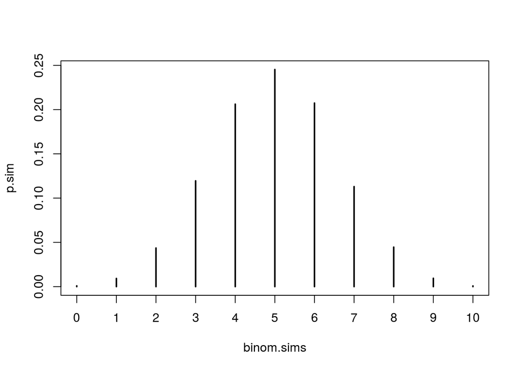

```r
plot(p.sim, type = 'h')
```

What we’ve done here is approximate a pmf using Monte Carlo simulation. Now let’s compare it to the *actual* pmf of a Binomial RV.

We know how to calculate this using what we covered in R Tutorial #5

```r
support <- 0:10
p.true <- dbinom(support, size = 10, prob = 0.5)
rbind(support, p.true)
```

```
##                 [,1]        [,2]       [,3]      [,4]      [,5]      [,6]
## support 0.0000000000 1.000000000 2.00000000 3.0000000 4.0000000 5.0000000
## p.true  0.0009765625 0.009765625 0.04394531 0.1171875 0.2050781 0.2460938
##              [,7]      [,8]       [,9]       [,10]        [,11]
## support 6.0000000 7.0000000 8.00000000 9.000000000 1.000000e+01
## p.true  0.2050781 0.1171875 0.04394531 0.009765625 9.765625e-04
```

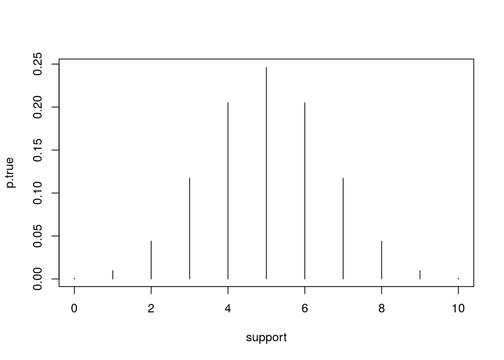

```r
plot(support, p.true, type = 'h')
```

The plot of the actual pmf and the associated probabilities match those from the simulation almost perfectly:

```r
p.sim - p.true
```

```
## binom.sims
##             0             1             2             3             4
## -0.0000965625 -0.0005156250 -0.0003353125  0.0023525000  0.0010818750
##             5             6             7             8             9
## -0.0008037500  0.0023318750 -0.0041775000  0.0006846875 -0.0003356250
##            10
## -0.0001865625
```

As you can see, the differences are *tiny*. They’d be even smaller if we used more replications.

**I hope this example has given you a bit more intuition about the Binomial RV. I’m not going to assign any exercises here, but it would be a good idea to try some simulation experiments of your own with different values for $n$ and $p$.**